# Study 1 Analysis

```r
# Welch;s t-test comparing the rejected and accepted groups
s1d_sensitivity_t <- t.test(formula = heart_T3 ~ rejection, data = S1d_data)
# get means and sd only for rejection vs acceptance
s1d_sensitivity_APA <- describe_by_factor(S1d_data, rejection, vars = heart_T3) %>%
  mutate(msd = to_msd(heart_T3_mean, heart_T3_sd)) %>% select(rejection, msd) %>%
  deframe() %>% as.list()
s1d_sensitivity_d <- effectsize::cohens_d(x = heart_T3 ~ rejection, data = S1d_data)
# Get the RMD object
s1d_sensitivity_APA <- s1d_sensitivity_APA %>%
  append(list(t = describe.ttest(s1d_sensitivity_t),
              d = describe_d_ci(s1d_sensitivity_d)))
```

**Sensitivity to Experimental Manipulation.** To test the sensitivity of the Heart Manikin to experimental manipulation, I ran Welch’s t-test comparing the rejected and accepted participants at Time 3. Results showed that rejected participants (*M* = 5.77, *SD* = 2.01) reported lower Heart Manikin scores than accepted participants (*M* = 6.88, *SD* = 1.39, *t*(205.5) = 4.95, *p* < .001).

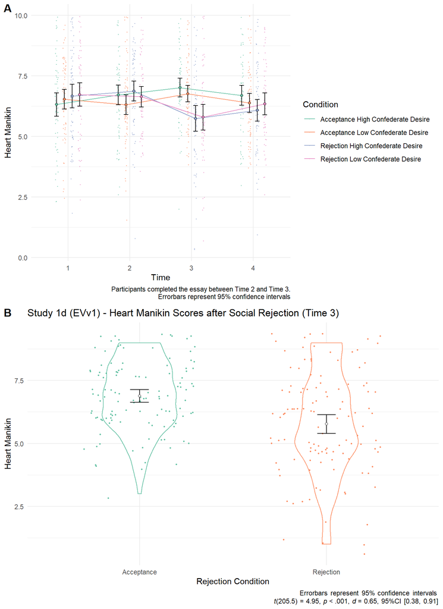

```r
# Study 1d (EVv1) - Outcome: heart T3
s1d_T3heart_plot <- S1d_data %>%
  ggplot(aes(x = rejection, y = heart_T3, color = rejection)) +
  # Render the default violin plot
  default_violin +
  ggtitle("Study 1d (EVv1) - Heart Manikin Scores after Social Rejection (Time 3)") +
  # Labels
  xlab("Rejection Condition") +
  ylab("Heart Manikin") +
  scale_fill_brewer(palette = "Set2") +
  scale_color_brewer(palette = "Set2", name = "Condition") +
  guides(color = FALSE) +
  labs(caption = paste(sep = "<br>",
                       "Errorbars represent 95% confidence intervals",
                       paste(s1d_sensitivity_APA$t, s1d_sensitivity_APA$d, sep = ", ")))

# S1d Plot - Heart by Condition across time
s1d_heart_plot <- S1d_dataC_long %>%
  ggplot(aes(x = time, y = heart, color = paste(rejection, confederate_desire), group = paste(rejection, confederate_desire))) +
  # Plot Data Points
  geom_point(position = position_jitterdodge(jitter.height = 1,
                                             jitter.width = .05, dodge.width = my_dodge_width),
             size = .2) +
  # Add line to connect the groups
  geom_line(stat = "summary", fun.data = mean_cl_normal, position = dodge_pos) +
  geom_errorbar(fun.data = mean_cl_normal, stat = "summary", width = .3,
                position = dodge_pos, color = "black") +
  # Plot means
  geom_point(stat = "summary", fun.data = mean_cl_normal,
             shape = 21, aes(fill = paste(rejection, confederate_desire)), color = "black",
             position = dodge_pos) +
  # Labels
  xlab("Time") +
  ylab("Heart Manikin") +
  scale_fill_brewer(palette = "Set2") +
  scale_color_brewer(palette = "Set2", name = "Condition") +
  guides(fill = FALSE) +
  labs(caption = "Participants completed the essay between Time 2 and Time 3.\nErrorbars represent 95% confidence intervals")

# GGarrange to put the plots together
ggarrange(s1d_heart_plot, s1d_T3heart_plot,
          labels = "AUTO", ncol = 1)
```

```r
# Model
S1d_test_retest_model <- lmer(formula = heart ~ 1 + confederate_desire_ec * rejection_ec * time + (1|id),
                              data = S1d_dataC_long)
# Calculate ICC
S1d_test_retest_icc <- performance::icc(S1d_test_retest_model)
S1d_reliability_txt <- list(icc = S1d_test_retest_icc$ICC_adjusted %>% round(2),
                            mean_interval = NA)
```

**Test-Retest Reliability.** To test test-retest reliability, I created a linear mixed model predicting the Heart Manikin scores. The fixed predictor was the same as the above model testing convergent and discriminant validity except that the model did not include the measured score predictor. Results showed that the calculated ICC was 0.75, suggesting a moderate-to-good reliability of the Heart Manikin measure across Times 1 to 4.

Across Studies 1a, 1b, 1c, and 1d, I validated the Heart Manikin measure. In the next study, I continued the validation. In addition, I aimed to examine the effectiveness of the rejection manipulation that I planned to use for the subsequent studies.

# 5 Study 1e (NPSv2)

## 5.1 Procedure and Materials

(In-Text)

## 5.2 Participants

```r
# Variables used for the analysis ------------------------------------------
S1e_target_vars_labels <- c(
  # Heart Manikin
  "Heart T1" = "heart_T1",
  "Heart T2" = "heart_T2",
  "Heart T3" = "heart_T3",
  "Heart T4" = "heart_T4",
  "Heart T5" = "heart_T5",
  "Heart T6" = "heart_T6",
  # Valence Manikin
  "Valence T1" = "valence_T1",
  "Valence T2" = "valence_T2",
  "Valence T3" = "valence_T3",
  "Valence T4" = "valence_T4",
  "Valence T5" = "valence_T5",
  "Valence T6" = "valence_T6",
  # Arousal Manikin
  "Arousal T1" = "arousal_T1",
  "Arousal T2" = "arousal_T2",
  "Arousal T3" = "arousal_T3",
  "Arousal T4" = "arousal_T4",
  "Arousal T5" = "arousal_T5",
  "Arousal T6" = "arousal_T6",
  # Dominance Manikin
  "Dominance T1" = "dominance_T1",
  "Dominance T2" = "dominance_T2",
  "Dominance T3" = "dominance_T3",
  "Dominance T4" = "dominance_T4",
  "Dominance T5" = "dominance_T5",
  "Dominance T6" = "dominance_T6",
  "Attachment Avoidance T1" = "ECR_avoidance_mean",
  "Attachment Anxiety T1" = "ECR_anxiety_mean",
  "Fear of Negative Evaluation T1" = "FNES_mean",
  # Self-Esteem
  "Self-Esteem T1" = "esteem_mean",
  # Social Status
  "Subjective SES T1" = "ladder",
  # Rejection Sensitivity
  "Rejection Sensitivity T1" = "RS_mean",
  # Need-threat Scale (Times 3 & 5)
  "NTS Belonging T3" = "nts_T3_belonging_mean",
  "NTS Belonging T5" = "nts_T5_belonging_mean",
  "NTS Self-Esteem T3" = "nts_T3_esteem_mean",
  "NTS Self-Esteem T5" = "nts_T5_esteem_mean",
  "NTS Control T3" = "nts_T3_control_mean",
  "NTS Control T5" = "nts_T5_control_mean",
  "NTS Meaning T3" = "nts_T3_meaning_mean",
  "NTS Meaning T5" = "nts_T5_meaning_mean")

# regex .+?( = )
S1e_var_types <- c(
  # Valence Manikin
  "valence_T1"= "Convergent",
  "valence_T2"= "Convergent",
  "valence_T3"= "Convergent",
  "valence_T4"= "Convergent",
  "valence_T5"= "Convergent",
  "valence_T6"= "Convergent",
  # Arousal Manikin
  "arousal_T1"= "Discriminant",
  "arousal_T2"= "Discriminant",
  "arousal_T3"= "Discriminant",
  "arousal_T4"= "Discriminant",
  "arousal_T5"= "Discriminant",
  "arousal_T6"= "Discriminant",
  # Dominance Manikin
  "dominance_T1"= "Discriminant",
  "dominance_T2"= "Discriminant",
  "dominance_T3"= "Discriminant",
  "dominance_T4"= "Discriminant",
  "dominance_T5"= "Discriminant",
  "dominance_T6"= "Discriminant",
  # ECR Attachment Scales
  "ECR_avoidance_mean"= "Convergent (R)",
  "ECR_anxiety_mean"= "Convergent (R)",
  # Fear of Negative Evaluation
  "FNES_mean"= "Convergent (R)",
  # Self-Esteem
  "esteem_mean"= "Convergent",
  # Social Status
  "ladder"= "Discriminant",
  # Rejection Sensitivity
  "RS_mean"= "Convergent (R)",
  # Need-threat Scale (Times 3 & 5)
  "nts_T3_belonging_mean"= "Convergent",
  "nts_T5_belonging_mean"= "Convergent",
  "nts_T3_esteem_mean"= "Convergent",
  "nts_T5_esteem_mean"= "Convergent",
  "nts_T3_control_mean"= "Discriminant",
  "nts_T5_control_mean"= "Discriminant",
  "nts_T3_meaning_mean"= "Discriminant",
  "nts_T5_meaning_mean" = "Discriminant"
) %>%
  tibble(predictor = names(.), type = .) %>%
  mutate(predictor = fct_inorder(predictor),
         type = fct_relevel(type, levels = c("Convergent", "Convergent (R)", "Discriminant")))

# Subset the data to target variables only
S1e_data_target_only <- S1e_data %>%
  select(all_of(S1e_target_vars_labels))

# Labels keys df for later use
S1e_target_vars_labels_df <- tibble(predictor = S1e_target_vars_labels,
                                    label = names(S1e_target_vars_labels))
# Append to the vartypes
S1e_var_types <- S1e_var_types %>%
  left_join(S1e_target_vars_labels_df)

# Correlation analysis ---------------------------------------------------------
# Create CIs for Correlations
# Heart Manikin Variables
S1e_heart_vars <- c("Heart T1", "Heart T2", "Heart T3",
                    "Heart T4", "Heart T5", "Heart T6")
# Tibble to gather correlation models each Time do get_correlations
S1e_cor_CIs <- tibble(outcome = S1e_heart_vars) %>%
  mutate(cors = map(outcome, ~get_correlations(S1e_data_target_only,
                                               vars = `Valence T1`:`NTS Meaning T5`,
                                               outcome = .))) %>% unnest()
# Add validity types
S1e_cor_CIs <- S1e_cor_CIs %>%
  left_join(S1e_var_types)
# Add Times Variable
S1e_cor_CIs <- S1e_cor_CIs %>%
  mutate(time = str_extract(label, "T\\d"))
```

## 5.3 Results

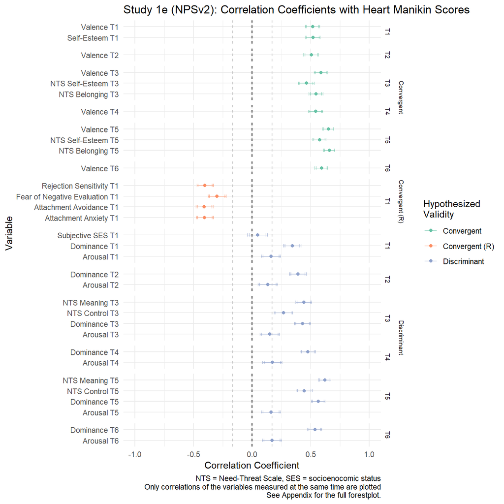

Figure 5.1: Study 1e: Correlations with the Heart Manikin

```r
# Study 1e - Correlations Forest Plot - only nonrepeats
S1e_cor_CIs_concurrent <- S1e_cor_CIs %>%
  # Only those that were measured at the same time
  filter(str_extract(outcome, ".$") == str_extract(label, ".$")) %>%
  mutate(predictor_name = str_extract(predictor, ".+[_]") %>% str_replace("_", ""))
# filter(!(predictor_name %in% c("valence", "dominance", "arousal")))

S1e_cor_CIs_concurrent %>%
  ggplot(aes(y = label, x = estimate, color = type)) +
  # SESOI and Zero
  geom_zeroSESOI +
  # Data points
  geom_point()+
  # CI error bars - 90%
  geom_errorbarh(aes(xmin = conf.low_model90, xmax = conf.high_model90), height = .3, size = .3) +
  # CI error bars - 95%
  geom_errorbarh(aes(xmin = conf.low_model95, xmax = conf.high_model95), height = .3, size = .3) +
  # x-axis limits and label
  scale_x_continuous(limits=c(-1,1), name='Correlation Coefficient')+
  # y-axis label
  ylab('Variable') +
  # Legend Title
  scale_color_brewer(name = "Hypothesized \nValidity", palette = "Set2") +
  # Title
  ggtitle("Study 1e (NPSv2): Correlation Coefficients with Heart Manikin Scores") +
  # Smaller labels for the validity type
  theme(strip.text.y = element_text(size = 7)) +
  # Caption
  labs(caption = paste(sep = "\n",
                       "NTS = Need-Threat Scale, SES = socioenocomic status",
                       "Only correlations of the variables measured at the same time are plotted",
                       "See Appendix for the full forestplot.")) +
  #And allow them to have their own unique axes (so authors don't redundantly repeat)
  ggh4x::facet_nested(type + time ~ ., scales= 'free', space='free')
```

```r
# Effect coding and create dummy for participant and confederate desires
S1e_data <- S1e_data %>%
  mutate(participant_desire_ec = case_when(participant_desire == 0 ~ -0.5,
                                           participant_desire == 1 ~ 0.5),
         confederate_desire_ec = case_when(confederate_desire == 0 ~ -0.5,
                                           confederate_desire == 1 ~ 0.5),
         desires_dummy = case_when(participant_desire == 0 &
                                     confederate_desire == 0 ~ "P0C0",
                                   participant_desire == 0 &
                                     confederate_desire == 1 ~ "P0C1",
                                   participant_desire == 1 &
                                     confederate_desire == 0 ~ "P1C0",
                                   participant_desire == 1 &
                                     confederate_desire == 1 ~ "P1C1"))
# Standardize the dataset
S1e_data_std <- S1e_data %>%
  select(id, participant_desire, confederate_desire, desires_dummy, rejection,
         all_of(as.vector(S1e_target_vars_labels))) %>%
  # Standardize
  mutate(across(all_of(as.vector(S1e_target_vars_labels)),
                ~scale(.) %>% as.vector()))
# Long dataset (unstandardized)
S1e_data_long <- S1e_data %>%
  pivot_longer(c(heart_T1:heart_T6, valence_T1:valence_T6,
                 arousal_T1:arousal_T6, dominance_T1:dominance_T6)) %>%
  mutate(time = str_extract(name, "\\d"),
         name = str_replace(name, "_.\\d", "")) %>%
  pivot_wider(names_from = name, values_from = value)
# Prepare a long dataset
S1e_data_std_long <- S1e_data_std %>%
  select(id, participant_desire, confederate_desire, desires_dummy, rejection,
         heart_T1:heart_T6, valence_T1:valence_T6,
         arousal_T1:arousal_T6, dominance_T1:dominance_T6) %>%
  pivot_longer(c(-id, -desires_dummy, -rejection, -participant_desire, -confederate_desire)) %>%
  mutate(time = str_extract(name, "\\d"),
         name = str_replace(name, "_.\\d", "")) %>%
  pivot_wider(names_from = name, values_from = value)

# Run Mixed Lmer model --------------------------------------------------------
S1e_mixed_preds <- c("heart", "valence", "arousal", "dominance")
# Create a table of formula and their associated results
S1e_mixed_df <- tibble(predictor = S1e_mixed_preds[2:length(S1e_mixed_preds)]) %>%
  mutate(formula = paste0("heart ~ 1 + ", predictor, " + time + desires_dummy * rejection * time + (1|id)")) %>%
  mutate(model = map(formula, ~lmer(formula = ., data = S1e_data_std_long)),
         broom = map(model, ~broom.mixed::tidy(.)),
         target_pred = map(broom, ~.[2,])) %>%
  # Calculate confidence intervals - parm = 4 for the predictor
  mutate(ci95 = map(model, ~confint.merMod(parm = 4, ., method = "Wald", level = .95) %>%
                      as_tibble() %>% rename_with(~c("lower", "upper"))),
         ci90 = map(model, ~confint.merMod(parm = 4, ., method = "Wald", level = .90) %>%
                      as_tibble() %>% rename_with(~c("lower", "upper")))) %>%
  unnest(target_pred) %>%
  unnest(ci95, ci90, names_sep = "_")
# Add labels
S1e_mixed_df <- S1e_mixed_df %>%
  mutate(pred_label = c("Valence", "Arousal", "Dominance"))
# Add Type
S1e_mixed_df <- S1e_mixed_df %>%
  mutate(type = c("Convergent", "Discriminant", "Discriminant"))
```

For the Self-Assessment Manikin scores measured over Times 1–6, I constructed a linear mixed model predicting the Heart Manikin scores. I created a dummy categorical variable (Grouping Dummy) representing the four experimental conditions for Participant Desire and Confederate Desire to reduce the number of interactions in the model (coded as 0-3). I included the fixed effects of the measured scores (centered), Time (categorical), Dummy for the Participant desire and Confederate Desire conditions (categorical), social rejection (rejected = -.5, control = .5), Grouping Dummy, Grouping Dummy x Rejection, Rejection x Time, Rejection x Grouping Dummy, Rejection x Time x Grouping Dummy. Results showed that the Valence Manikin scores predicted the Heart Manikin scores after controlling for the manipulations and time, supporting the hypothesized convergent validity. However, the Arousal and Dominance Manikin scores also predicted the Heart Manikin scores, contrary to the expectation. Overall, the mixed model analyses showed a strong support for the convergent validity of the Heart Manikin, but no support for the discriminant valdiity with the Need-Threat Scale, the arousal and dominance manikins.

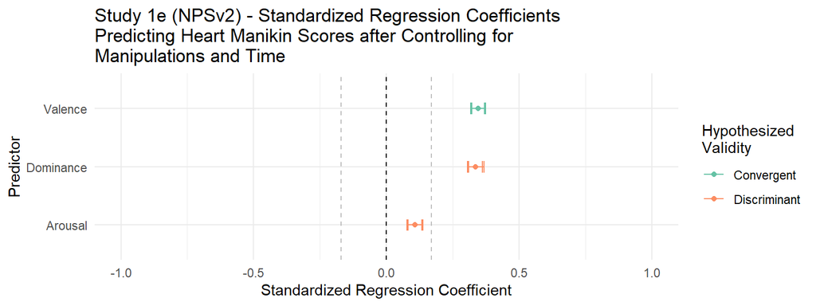

```r
# Forest Plot
S1e_mixed_df %>%
  ggplot(aes(y = pred_label, x = estimate, color = type)) +
  # Add lines for zero and SESOI
  geom_zeroSESOI +
  # Data points
  geom_point() +
  # CI error bars - 90%
  geom_errorbarh(aes(xmin = ci90_lower, xmax = ci90_upper), height = .2, size = .5) +
  # CI error bars - 95%
  geom_errorbarh(aes(xmin = ci95_lower, xmax = ci95_upper), height = .2, size = .5) +
  # x-axis limits and labels
  scale_x_continuous(limits=c(-1,1), name = "Standardized Regression Coefficient")+
  # y-axis label
  ylab("Predictor")+
  # Legend Title
  scale_color_brewer(name = "Hypothesized \nValidity", palette = "Set2") +
  #Add a vertical dashed line indicating an effect size of zero, for reference
  geom_vline(xintercept=0, color='black', linetype='dashed') +
  #Create sub-plots (i.e., facets) based on levels of setting
  ggtitle("Study 1e (NPSv2) - Standardized Regression Coefficients \nPredicting Heart Manikin Scores after Controlling for \nManipulations and Time") +
  # Add SESOI
  SESOIgeom
```

```r
# Welch;s t-test comparing the rejected and accepted groups
S1e_sensitivity_mod <- t.test(formula = heart_T5 ~ rejection,
                              data = S1e_data)
# get means and sd only for rejection vs acceptance
s1e_sensitivity_APA <- describe_by_factor(S1e_data, rejection, vars = heart_T5) %>%
  mutate(msd = to_msd(heart_T5_mean, heart_T5_sd)) %>% select(rejection, msd) %>%
  mutate(rejection = to_factor(rejection)) %>%
  deframe() %>% as.list()
# Get the cohens d and ci
s1e_sensitivity_dci <- effectsize::cohens_d(x = heart_T5 ~ rejection, data = S1e_data)
# RMD
s1e_sensitivity_APA <- s1e_sensitivity_APA %>%
  append(list(t = S1e_sensitivity_mod %>% describe.ttest(),
              d = s1e_sensitivity_dci %>% describe_d_ci())) %>%
  append(s1e_sensitivity_dci %>% as.list())
```

**Sensitivity to Experimental Manipulation.** To test the sensitivity of the Heart Manikin scores to a social rejection manipulation, I ran a Welch’s t-test comparing the rejected and control groups following the social rejection manipulation at Time 5. Results showed that the rejected participants (*M* = 6.47, *SD* = 1.88) had lower Heart Manikin scores than the control participants (*M* = 6.78, *SD* = 1.55, *t*(518.8) = 2.11, *p* = .036 , *d* = 0.18, 95%CI [0.01, 0.35]).

```r
# Model
S1e_test_retest_model <- lmer(formula = heart ~ 1 + desires_dummy * rejection * time + (1|id),
                              data = S1e_data_std_long)
# Calculate ICC
S1e_test_retest_icc <- performance::icc(S1e_test_retest_model)
# Text
S1e_reliability_txt <- list(icc = S1e_test_retest_icc$ICC_adjusted %>% round(2),
                            mean_interval = NA)
```

**Test-Retest Reliability.** To test test-retest reliability, I created a linear mixed model predicting the Heart Manikin scores across measurements. I included the same fixed effects as the aforementioned model testing the convergent and discriminant validity except that the model did not include a predictor for a measured score. The calculated ICC was 0.72, indicating a moderate test-retest reliability after controlling for the effects of the experimental manipulations.

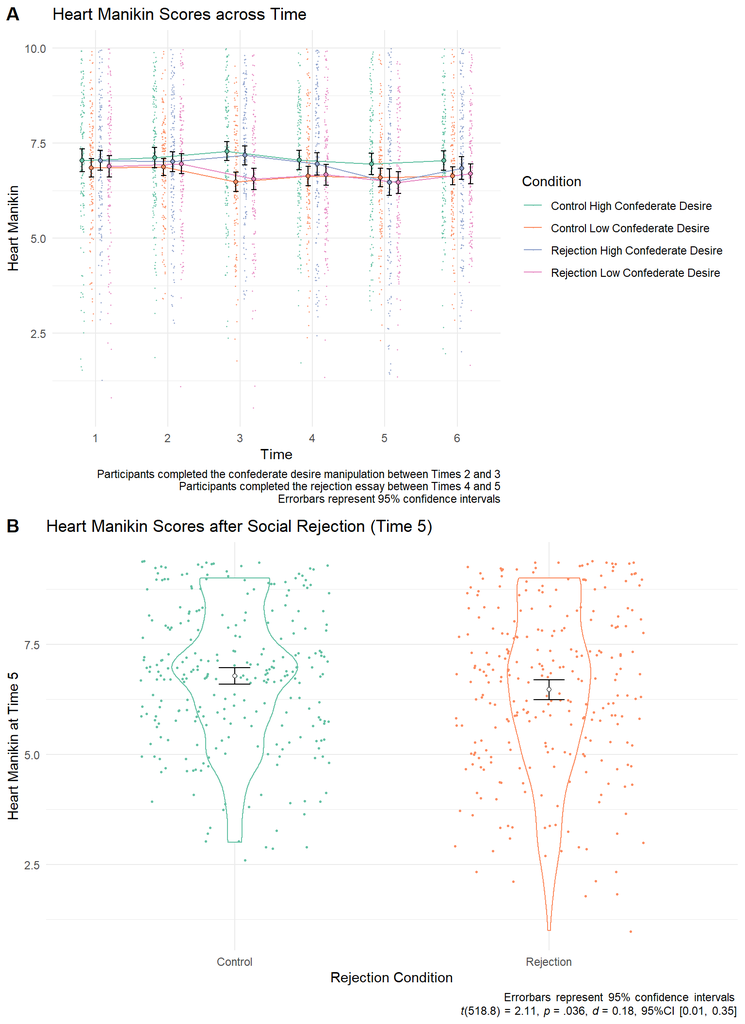

Figure 5.2: Study 1e - Heart Manikin Scores

```r
# Study 1e (EVv1) - Outcome: Heart Manikin at Time 5
s1e_T5_heart <- S1e_data %>%
  mutate(rejection = to_factor(rejection)) %>%
  ggplot(aes(x = rejection, y = heart_T5, color = rejection)) +
  # Render the default violin plot
  default_violin +
  # Labels
  ggtitle("Heart Manikin Scores after Social Rejection (Time 5)") +
  xlab("Rejection Condition") +
  ylab("Heart Manikin at Time 5") +
  scale_fill_brewer(palette = "Set2") +
  scale_color_brewer(palette = "Set2", name = "Condition") +
  guides(color = FALSE) +
  labs(caption = paste(sep = "<br>",
                       "Errorbars represent 95% confidence intervals",
                       paste(s1e_sensitivity_APA$t, s1e_sensitivity_APA$d, sep = ", ")))

# S1e Plot - Heart by Condition across time
s1e_heart_plot <- S1e_data_long %>%
  mutate(across(c(rejection, confederate_desire), to_factor)) %>%
  ggplot(aes(x = time, y = heart, color = paste(rejection, confederate_desire),
             group = paste(rejection, confederate_desire))) +
  # Plot Data Points
  geom_point(position = position_jitterdodge(jitter.height = 1,
                                             jitter.width = .05, dodge.width = my_dodge_width),
             size = .2) +
  # Add line to connect the groups
  geom_line(stat = "summary", fun.data = mean_cl_normal, position = dodge_pos) +
  geom_errorbar(fun.data = mean_cl_normal, stat = "summary", width = .3,
                position = dodge_pos, color = "black") +
  # Plot means
  geom_point(stat = "summary", fun.data = mean_cl_normal,
             shape = 21, aes(fill = paste(rejection, confederate_desire)), color = "black",
             position = dodge_pos) +
  # Labels
  ggtitle("Heart Manikin Scores across Time") +
  xlab("Time") +
  ylab("Heart Manikin") +
  scale_fill_brewer(palette = "Set2") +
  scale_color_brewer(palette = "Set2", name = "Condition") +
  guides(fill = FALSE) +
  labs(caption = paste(sep = "\n",
                       "Participants completed the confederate desire manipulation between Times 2 and 3",
                       "Participants completed the rejection essay between Times 4 and 5",
                       "Errorbars represent 95% confidence intervals"))


# GGarrange to put the plots together
ggarrange(s1e_heart_plot, s1e_T5_heart,
          labels = "AUTO", ncol = 1)
```

```r
s1e_NTS_T5_vars <- c("nts_T5_belonging_mean", "nts_T5_esteem_mean",
                     "nts_T5_control_mean", "nts_T5_meaning_mean",
                     "nts_T5_mean")

s1e_NTS_T5_df <- tibble(outcome = s1e_NTS_T5_vars) %>%
  mutate(formula = (paste0(outcome, " ~ rejection"))) %>%
  mutate(fit = map(formula, ~t.test(formula = as.formula(.),
                                    data = S1e_data))) %>%
  mutate(broom = map(fit, ~broom::tidy(.)),
         ci95 = map(formula, ~effectsize::cohens_d(x = as.formula(.),
                                                   data = S1e_data, ci = .95)),
         ci90 = map(formula, ~effectsize::cohens_d(x = as.formula(.),
                                                   data = S1e_data, ci = .90))) %>%
  # Get APA
  mutate(t_APA = map_chr(fit, describe.ttest)) %>%
  mutate(across(c(ci95, ci90), list(APA = ~map_chr(., describe_d_ci)))) %>%
  mutate(td_APA = str_c(t_APA, ci95_APA, sep = ", "))
# RMD
S1e_NTS_APA <- s1e_NTS_T5_df %>% select(outcome, td_APA) %>% deframe %>% as.list
# Means and SDs for per conditions
S1e_NTS_desc <- S1e_data %>% describe_by_factor(rejection, vars = s1e_NTS_T5_vars) %>%
  mutate(rejection = to_factor(rejection)) %>%
  get_APA_from_msd(group_cols = "rejection") %>%
  mutate(variable = str_remove(variable, "_mean")) %>%
  mutate(label = paste0(str_extract(rejection, "^."), variable))
# Get the descriptives into the list format and append it to the APA list for rmd
S1e_NTS_APA <- S1e_NTS_APA %>%
  append(S1e_NTS_desc %>% select(label, APA) %>% deframe() %>% as.list)
```

**Effectiveness of Rejection Manipulation on Belonging.** To test the effectiveness of the rejection manipulation on belonging, I performed a series of Welch’s t-tests on the belonging subscale of the Need-Threat Scale at Time 5 (Figure 5.3). Results showed that participants in the rejection condition reported lower belonging (*M* = 79.13, *SD* = 16.68) than those in the control condition (*M* = 82.04, *SD* = 14.18, *t*(521.6) = 2.18, *p* = .030, *d* = 0.19, 95%CI [0.02, 0.36]), indicating that the manipulation was effective. I also ran Welch’s t-tests on other subscales of the need-threat scale (self-esteem, control, and meaningful existence). Results showed that rejected participants and control participants did not report different levels of self-esteem, control, meaningful existence, or the overall need-threat (self-esteem: *t*(524.4) = 1.71, *p* = .088, *d* = 0.15, 95%CI [-0.02, 0.32], control: *t*(536.0) = -0.63, *p* = .531, *d* = -0.05, 95%CI [-0.22, 0.12], meaning: *t*(527.8) = 1.78, *p* = .075, *d* = 0.15, 95%CI [-0.02, 0.32], overall need-threat: *t*(524.9) = 1.46, *p* = .145, *d* = 0.13, 95%CI [-0.04, 0.30]). These results suggest that although the rejection manipulation was effective in inducing lowered belonging, it may not be effective in lowering self-esteem, control, meaningful existence, or overall fundmental need.

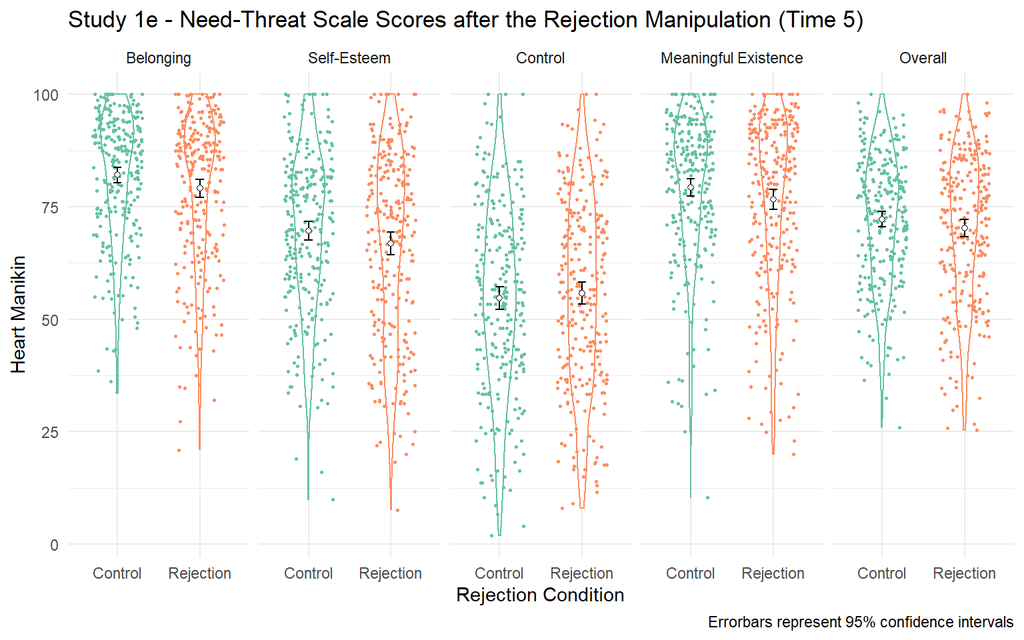

Figure 5.3: Study 1e - Need-Threat Scores Across Rejection and Control Conditions

```r
# Study 1e - NTS scores by rejection condition
S1e_NTS_long <- S1e_data %>%
  pivot_longer(matches("T5.+mean")) %>%
  # labels
  mutate(labels = fct_recode(name,
                             "Belonging" = "nts_T5_belonging_mean",
                             "Self-Esteem" = "nts_T5_esteem_mean",
                             "Control" = "nts_T5_control_mean",
                             "Meaningful Existence" = "nts_T5_meaning_mean",
                             "Overall" = "nts_T5_mean") %>%
           # Change Order by fct_relevel()
           fct_relevel("Belonging", "Self-Esteem", "Control", "Meaningful Existence", "Overall"))
# Plot
S1e_NTS_long %>%
  ggplot(aes(x = rejection %>% to_factor(), y = value, color = rejection %>% to_factor())) +
  # Render the default violin plot
  default_violin +
  ggtitle("Study 1e - Need-Threat Scale Scores after the Rejection Manipulation (Time 5)") +
  # Labels
  xlab("Rejection Condition") +
  ylab("Heart Manikin") +
  scale_fill_brewer(palette = "Set2") +
  scale_color_brewer(palette = "Set2", name = "Condition") +
  guides(color = FALSE) +
  labs(caption = paste(sep = "<br>",
                       "Errorbars represent 95% confidence intervals")) +
  facet_wrap(. ~ labels, ncol = 5)
```

```r
S1c_data_rej <- S1c_data %>% filter(acceptance == "0")
s1c_heart_time_dci <- S1c_data_rej %>% effectsize::cohens_d(x = .$heart1, y = .$heart2, paired = T)
# APA-formatted t and d values with CI's
s1c_heart_time <- list(t = S1c_data_rej %>% t.test(formula = Pair(heart1, heart2) ~ 1, data = .) %>%
                         describe.ttest(),
                       d = s1c_heart_time_dci %>% describe_d_ci())
# Append the actual values of cohens d to the list
s1c_heart_time <- s1c_heart_time %>% append(s1c_heart_time_dci %>% as.list())
# Study 1d
s1d_heart_time <- S1d_data %>% t.test(formula = Pair(heart_T2, heart_T3) ~ 1, data = .)
```

# 6 Rejection Manipulation

The effect size for the rejection manipulation of Study 1e was small *d* = 0.18, 95%CI [0.01, 0.35]. Also, the manipulation did not lower the fundamental needs that usually track with the rejection manipulations in the other studies (Williams et al. 2005). These results raised a concern about the effectiveness of the rejection manipulation. Since I plan to use the rejection manipulation without a control or acceptance condition, I wanted to ensure the effectiveness of the manipulation. These results suggested that the manipulation used in Study 1e may not be optimal to use the purposes of this dissertation.

# 7 Discussion

Across 5 studies, I examined the convergent validity, discriminant validity, and test-retest reliability of the Heart Manikin. I tested convergent and discriminant validities, test-retest reliability, and sensitivity to social rejection manipulation.

**Convergent Validity.** The Heart Manikin scores correlated with the hypothesized convergent measures: belonging need-threat (Studies 1c, 1d, and 1e), social isolation (Study 1a), interpersonal relationship quality and conflict (Study 1b), depression (Studies 1a and 1b), and valence (Studies 1a, 1b, 1c, 1d, and 1e). The current results strongly support that the Heart Manikin scores can converge with belonging and its associated measures.

Although this is a result-dependent reasoning, I can see that some of these measures can correlate with belonging. For example, people with multiple identity could report more belonging since they belong to multiple groups, people with higher social monitoring can cultivate social connections easily, people who do not threaten their partner experience more loving interactions. People with higher threats to belonging experience emotional distress and thus they report higher stress scores than those with lower threats to belonging (Williams et al. 2005). Similarly, people with lowered belonging report lowered control and meaningful existence (Williams et al. 2005). I do not have post-hoc explanations for why people with higher Heart Manikin scores reported lower narcissism, less biological beliefs in differences between Black and White people, and higher socioeconomic status.

Note that some of the associations that are found can be attributed to Type I error. For example, I found the association between the socioeconomic status and the Heart Manikin in Study 1c, but not in Studies 1 b and 1e, adding to the possibility of Type I error. In contrast, this possibility of Type I error is less likely for control need, meaningful existence need, arousal, and dominance since I observed the associations for these measures across two studies (Studies 1c and 1e).

Overall, I conclude that Study 1 supported the convergent validity of the Heart Manikin. The results for the discriminant validity was not very strong. However, some of the hypothesized discriminant measures are known to be associated with belonging (e.g., control and meaningful existence needs). I suggest that the Heart Manikin scores track belonging well but do not necessarily distinguish belonging from other related constructs, including general stress, control and meaningful existence needs. Given the promising results of the convergent validity, I decided to use the Heart Manikin sores as key outcome variable.

The current study has constraints of generality. First, I used existing data for the current validation. As a result, the sample sizes of the studies were not based on a proper power analysis, making the results susceptible to Type I and Type II errors. In addition, the measures in the studies were not a priori selected to validate the Heart Manikin. Second, the sample demographics were limited to undergraduate students from an introductory psychology course at the University of Delaware. Most participants were young and predominantly White, and thus I do not know if the current results generalize outside this sample to samples with different characteristics. Despite the shortcomings, the current study included 65 measures from 5 studies, and thus maximizing the generality across measures and studies. In the next studies, I will use the Hart Manikin as a primary outcome measure. a

Williams, Kipling D., Joseph P. Forgas, William Von Hippel, Joseph P. Forgas, and William Von Hippel. 2005. *The Social Outcast : Ostracism, Social Exclusion, Rejection, and Bullying*. Psychology Press. https://doi.org/10.4324/9780203942888.

———. 2005. *The Social Outcast : Ostracism, Social Exclusion, Rejection, and Bullying*. Psychology Press. https://doi.org/10.4324/9780203942888.